# Reproducible Research Final Project A study of Severe Weather Events

## Project Summary

The goal of this project is to download and explore a NOAA Storm Database that contains information about severe weather evets in the US. Throughout this exploration we will use tables, figures and summaries to examine the event data and to answer two questions:

- Across the United States, which types of events (as indicated in the EVTYPE variable) are most harmful with respect to population health?
- Across the United States, which types of events have the greatest economic consequences?

## Downloading and Loading the data

To begin we will download the data from NOAA and load it into R. We will then read the data from the file into an R table.

```r
# Download the data
download.file('https://d396qusza40orc.cloudfront.net/repdata%2Fdata%2FStormData.csv.bz2','stormData.csv.bz2')

# Now unpack the data
stormData <- read.csv('stormData.csv.bz2')
```

## Analyzing the import data set

We begin our analysis by summarizing the contents of the data set. What we find is that there are 902,297 events in the database. Each event has a recorded beginning and eng time, location - state, county, longitude and latitude, type, range, and damage count - fatalities, injuries, and property damanges.

```r
summary(stormData)
```

```
##     STATE__                  BGN_DATE             BGN_TIME
##  Min.   : 1.0   5/25/2011 0:00:00:  1202   12:00:00 AM: 10163
##  1st Qu.:19.0   4/27/2011 0:00:00:  1193   06:00:00 PM:  7350
##  Median :30.0   6/9/2011 0:00:00 :  1030   04:00:00 PM:  7261
##  Mean   :31.2   5/30/2004 0:00:00:  1016   05:00:00 PM:  6891
##  3rd Qu.:45.0   4/4/2011 0:00:00 :  1009   12:00:00 PM:  6703
##  Max.   :95.0   4/2/2006 0:00:00 :   981   03:00:00 PM:  6700
##                 (Other)          :895866   (Other)    :857229
##    TIME_ZONE          COUNTY           COUNTYNAME         STATE
##  CST    :547493   Min.   :  0.0   JEFFERSON :  7840   TX     : 83728
##  EST    :245558   1st Qu.: 31.0   WASHINGTON:  7603   KS     : 53440
##  MST    : 68390   Median : 75.0   JACKSON   :  6660   OK     : 46802
##  PST    : 28302   Mean   :100.6   FRANKLIN  :  6256   MO     : 35648
##  AST    :  6360   3rd Qu.:131.0   LINCOLN   :  5937   IA     : 31069
##  HST    :  2563   Max.   :873.0   MADISON   :  5632   NE     : 30271
##  (Other):  3631                   (Other)   :862369   (Other):621339
##                EVTYPE         BGN_RANGE           BGN_AZI
##  HAIL             :288661   Min.   :   0.000          :547332
##  TSTM WIND        :219940   1st Qu.:   0.000   N      : 86752
##  THUNDERSTORM WIND: 82563   Median :   0.000   W      : 38446
##  TORNADO          : 60652   Mean   :   1.484   S      : 37558
##  FLASH FLOOD      : 54277   3rd Qu.:   1.000   E      : 33178
##  FLOOD            : 25326   Max.   :3749.000   NW     : 24041
##  (Other)          :170878                      (Other):134990
##          BGN_LOCATI                  END_DATE             END_TIME
##               :287743                    :243411              :238978
##  COUNTYWIDE   : 19680   4/27/2011 0:00:00:  1214   06:00:00 PM:  9802
##  Countywide   :   993   5/25/2011 0:00:00:  1196   05:00:00 PM:  8314
##  SPRINGFIELD  :   843   6/9/2011 0:00:00 :  1021   04:00:00 PM:  8104
##  SOUTH PORTION:   810   4/4/2011 0:00:00 :  1007   12:00:00 PM:  7483
##  NORTH PORTION:   784   5/30/2004 0:00:00:   998   11:59:00 PM:  7184
##  (Other)      :591444   (Other)          :653450   (Other)    :622432
##    COUNTY_END COUNTYENDN       END_RANGE           END_AZI
##  Min.   :0    Mode:logical   Min.   :  0.0000          :724837
##  1st Qu.:0    NA's:902297    1st Qu.:  0.0000   N      : 28082
##  Median :0                   Median :  0.0000   S      : 22510
##  Mean   :0                   Mean   :  0.9862   W      : 20119
##  3rd Qu.:0                   3rd Qu.:  0.0000   E      : 20047
##  Max.   :0                   Max.   :925.0000   NE     : 14606
##                                                 (Other): 72096
```

[output cut: 41 more lines]

```
##  Min.   :   0   Min.   :-14451   Min.   :   0   Min.   :-14455
##  1st Qu.:2802   1st Qu.:  7247   1st Qu.:   0   1st Qu.:     0
##  Median :3540   Median :  8707   Median :   0   Median :     0
##  Mean   :2875   Mean   :  6940   Mean   :1452   Mean   :  3509
##  3rd Qu.:4019   3rd Qu.:  9605   3rd Qu.:3549   3rd Qu.:  8735
##  Max.   :9706   Max.   : 17124   Max.   :9706   Max.   :106220
##  NA's   :47                      NA's   :40
##                                            REMARKS           REFNUM
##                                                :287433   Min.   :     1
##                                                : 24013   1st Qu.:225575
##  Trees down.\n                                 :  1110   Median :451149
##  Several trees were blown down.\n              :   568   Mean   :451149
##  Trees were downed.\n                          :   446   3rd Qu.:676723
##  Large trees and power lines were blown down.\n:   432   Max.   :902297
##  (Other)                                       :588295
```

```r
summary(harmfulData)
```

```
##                   Group.1          x
##     HIGH SURF ADVISORY:  1   Min.   :    0
##   COASTAL FLOOD       :  1   1st Qu.:    0
##   FLASH FLOOD         :  1   Median :    0
##   LIGHTNING           :  1   Mean   :  158
##   TSTM WIND           :  1   3rd Qu.:    0
##   TSTM WIND (G45)     :  1   Max.   :96979
##  (Other)              :979
```

## Which events cause the most harm to people?

```r
# Sort the data
sortedHarmfulData<-harmfulData[order(-harmfulData$x),]

# Display the results - top 20 types of events that cause fatalities or injuries
head(sortedHarmfulData,20)
```

```
##                Group.1     x
## 834            TORNADO 96979
## 130     EXCESSIVE HEAT  8428
## 856          TSTM WIND  7461
## 170              FLOOD  7259
## 464          LIGHTNING  6046
## 275               HEAT  3037
## 153        FLASH FLOOD  2755
## 427          ICE STORM  2064
## 760  THUNDERSTORM WIND  1621
## 972       WINTER STORM  1527
## 359          HIGH WIND  1385
## 244               HAIL  1376
## 411  HURRICANE/TYPHOON  1339
## 310         HEAVY SNOW  1148
## 957           WILDFIRE   986
## 786 THUNDERSTORM WINDS   972
## 30            BLIZZARD   906
## 188                FOG   796
## 585        RIP CURRENT   600
## 955   WILD/FOREST FIRE   557
```

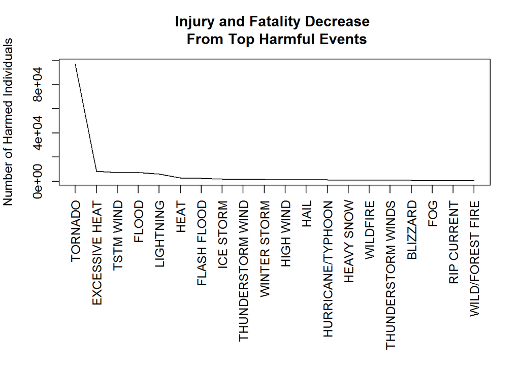

```r
# now plot the top 20 most harmful events
par(mar=c(12.5,4,4,2)) # First set the margins so that the labels are not cut off

# plot the data
plot(sortedHarmfulData$x[1:20],type='l',main="Injury and Fatality Decrease \n From Top Harmful Events",xlab="",ylab = 'Number of Harmed Individuals',xaxt = "n")

# Lastly label the events on the X axis
axis(1,1:20,labels =sortedHarmfulData$Group.1[1:20],las=2)
```

## Which events cause the most economic damage?

We now move onto the next question, which events cause the most economic damage. Looking at the original data summary we can argue that economic damage falls into two categories: property damage and crop damage. We repeat the analysis above but this time for economic damage.

```r
# add the human harm column
stormData['EconDamage']<-stormData$PROPDMG+stormData$CROPDMG

# Now collect the data based on the new column
econDamageData <- aggregate(stormData$EconDamage, list(stormData$EVTYPE), sum)

# Now sort the data by the damage numbers
sortedEconData<-econDamageData[order(-econDamageData$x),]

# Display the results - top 20 types of events that cause fatalities or injuries
head(sortedEconData,20)
```

```
##                Group.1          x
## 834            TORNADO 3312276.68
## 153        FLASH FLOOD 1599325.05
## 856          TSTM WIND 1445168.21
## 244               HAIL 1268289.66
## 170              FLOOD 1067976.36
## 760  THUNDERSTORM WIND  943635.62
## 464          LIGHTNING  606932.39
## 786 THUNDERSTORM WINDS  464978.11
## 359          HIGH WIND  342014.77
## 972       WINTER STORM  134699.58
## 310         HEAVY SNOW  124417.71
## 957           WILDFIRE   88823.54
## 427          ICE STORM   67689.62
## 676        STRONG WIND   64610.71
## 290         HEAVY RAIN   61964.94
## 376         HIGH WINDS   57384.60
## 848     TROPICAL STORM   54322.80
## 955   WILD/FOREST FIRE   43534.49
## 95             DROUGHT   37997.67
## 164     FLASH FLOODING   33623.20
```

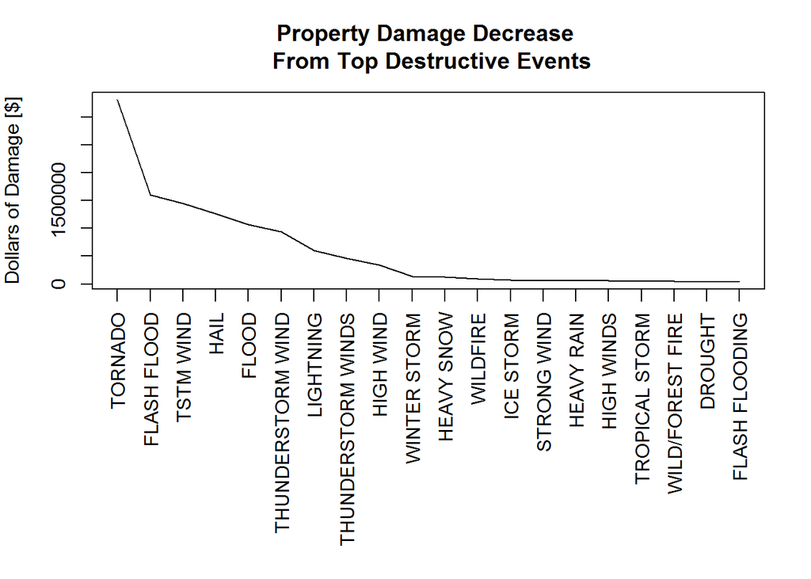

```r
# now plot the top 20 most destructive events
par(mar=c(12.5,4,4,2)) # First set the margins so that the labels are not cut off

# plot the data
plot(sortedEconData$x[1:20],type='l',main="Property Damage Decrease \n From Top Destructive Events",xlab="",ylab = 'Dollars of Damage [$]',xaxt = "n")

# Lastly label the events on the X axis
axis(1,1:20,labels =sortedEconData$Group.1[1:20],las=2)
```